# PricePulse: Unraveling Trends in Industrial Food Pricing

Lohit Marla

2023-12-29

## Introduction:

In the dynamic landscape of the industrial food sector, understanding and predicting fluctuations in the Total Industrial Product Price Index (IPPI) is essential for informed decision-making. The IPPI serves as a critical economic indicator, reflecting changes in the prices of a basket of goods representing the industrial food market. This project focuses on harnessing the power of statistical modeling techniques to predict the Total IPPI, leveraging key predictors within the industry.

## Abstract:

This project centers on the exploration and prediction of the Total Industrial Product Price Index (IPPI) in the industrial food domain. Spanning the timeline from January 1956 to November 2023, the dataset encapsulates a rich historical perspective of the industrial food market. The response variable, Total IPPI, stands as a barometer for the overall pricing trends within the sector.

Key predictors, namely Fresh and Frozen Beef and Veal, Fresh and Frozen Pork, Fresh and Frozen Lamb, Mutton, and Goat Meat, Complete Cattle Feed, and Complete Swine Feed, have been identified as pivotal influencers on the Total IPPI. These predictors, drawn from the industrial food landscape, encapsulate critical components that contribute to the overall pricing dynamics.

The project employs two powerful modeling approaches – Linear Regression and ARIMA. The Linear Regression model unveils the relationships between the response variable and predictors, shedding light on the impact of each factor on the Total IPPI. Additionally, the ARIMA model harnesses the temporal dependencies within the data to make time-sensitive predictions.

The outputs from these models are scrutinized, providing insights into the statistical significance of predictors, model fit, and future projections. Through a comprehensive analysis of residuals, variance inflation factors (VIF), and principal component analysis (PCA), the project aims to deliver a robust and interpretable framework for forecasting Total IPPI in the industrial food sector.

By blending historical context, advanced statistical techniques, and a keen focus on key predictors, this project endeavors to provide a nuanced understanding of pricing dynamics in the industrial food market. The outcomes hold the potential to empower stakeholders with actionable insights, enabling them to navigate the complexities of the evolving industrial food landscape.

```r
library(forecast)
library(caret)
library(car)
industrial.price.data <- read.csv("~/Documents/GitHub/GitHub/Industrial-Products-Price-Forecast/data/food_data_selected.csv")

#renaming the columns
names(industrial.price.data) <- gsub("[[:space:][:digit:]]", "", names(industrial.price.data))

#eliminated the North.American.Product.Classification.System..NAPCS. column
industrial.price.data <- industrial.price.data[2: ncol(industrial.price.data)]

#verifying the columns for numeric values and removing the non numeric columns
numeric_columns <- sapply(industrial.price.data, is.numeric)
columns_with_missing_values <- colnames(industrial.price.data)[colSums(is.na(industrial.price.data[numeric_columns])) > 0]

# Impute missing values in numeric columns with the mean
for (col in columns_with_missing_values) {
  mean_value <- mean(industrial.price.data[, col], na.rm = TRUE)
  mean_value_ <- round(mean_value, 2)
  industrial.price.data[, col][is.na(industrial.price.data[, col])] <- mean_value_
}

# Identify columns with all null values
empty_columns <- colnames(industrial.price.data)[colSums(is.na(industrial.price.data)) >= 1]

#removing constant values
# Check for constant columns
constant_columns <- names(which(sapply(industrial.price.data, function(x) length(unique(x)) == 1)))
# Print the constant columns
print(constant_columns)
```

```
## character(0)
```

```r
# Remove constant columns
industrial.price.data <- industrial.price.data[, !names(industrial.price.data) %in% constant_columns]
```

```r
#linear regression model
lmr_model <- lm(Total..Industrial.product.price.index..IPPI. ~ ., data = as.data.frame(industrial.price.data))
summary(lmr_model)
```

```
##
## Call:
## lm(formula = Total..Industrial.product.price.index..IPPI. ~ .,
##     data = as.data.frame(industrial.price.data))
##
## Residuals:
##      Min       1Q   Median       3Q      Max
## -25.4245  -2.1876   0.0533   3.2509  12.1078
##
## Coefficients:
##                                                Estimate Std. Error t value
## (Intercept)                                    -4.12094    0.53434  -7.712
## Fresh.and.frozen.beef.and.veal...               0.06048    0.02114   2.861
## Fresh.and.frozen.pork...                        0.32009    0.01798  17.806
## Fresh.and.frozen.lamb..mutton.and.goat.meat...  0.31051    0.01843  16.851
## Complete.cattle.feed...                         0.05913    0.03555   1.663
## Complete.swine.feed...                          0.40758    0.03198  12.746
##                                                Pr(>|t|)
## (Intercept)                                    3.63e-14 ***
## Fresh.and.frozen.beef.and.veal...               0.00433 **
## Fresh.and.frozen.pork...                        < 2e-16 ***
## Fresh.and.frozen.lamb..mutton.and.goat.meat...  < 2e-16 ***
## Complete.cattle.feed...                         0.09669 .
## Complete.swine.feed...                          < 2e-16 ***
## ---
## Signif. codes:  0 '***' 0.001 '**' 0.01 '*' 0.05 '.' 0.1 ' ' 1
##
## Residual standard error: 5.017 on 809 degrees of freedom
## Multiple R-squared:  0.9763, Adjusted R-squared:  0.9762
## F-statistic:  6673 on 5 and 809 DF,  p-value: < 2.2e-16
```

**Residuals:** Min: The minimum value of the residuals is -25.4245. 1Q (First Quartile): The value below which 25% of the residuals fall is -2.1876. Median: The median (50th percentile) of the residuals is 0.0533. 3Q (Third Quartile): The value below which 75% of the residuals fall is 3.2509. Max: The maximum value of the residuals is 12.1078.

**Coefficients:** (Intercept): The intercept of the regression line is estimated to be -4.12094. Fresh.and.frozen.beef.and.veal…: The coefficient for this variable is 0.06048, indicating the estimated change in the response variable for a one-unit change in this predictor. Fresh.and.frozen.pork…: The coefficient for this variable is 0.32009. Fresh.and.frozen.lamb..mutton.and.goat.meat…: The coefficient for this variable is 0.31051. Complete.cattle.feed…: The coefficient for this variable is 0.05913. Complete.swine.feed…: The coefficient for this variable is 0.40758.

**Residual Standard Error:** The standard deviation of the residuals is approximately 5.017. R-squared and Adjusted R-squared: Multiple R-squared: The proportion of variance in the response variable explained by the model is 97.63%. Adjusted R-squared: Similar to R-squared but adjusted for the number of predictors.

**F-Statistic:** The F-statistic tests the overall significance of the model. A high F-statistic with a low p-value (p-value: < 2.2e-16) suggests that at least one predictor variable is significantly related to the response variable. Interpretation: The model appears to fit the data well, as indicated by the high R-squared values. Each coefficient represents the estimated change in the response variable for a one-unit change in the corresponding predictor, assuming other predictors are held constant. The p-values associated with each coefficient suggest that most predictors are statistically significant in predicting the response variable. Ensure that the assumptions of linear regression are met, and consider the context of your analysis for a more in-depth interpretation.

In this analysis, we conducted a linear regression to understand the relationship between the Total Industrial Product Price Index (IPPI) and various predictor variables in the business context. The goal is to identify factors that significantly influence the total industrial product prices.

**Residuals:** The residuals represent the differences between the actual and predicted values of the Total IPPI. The model seems to have reasonably low residuals, suggesting that it fits the data well.

**Model Fit:** The overall model explains about 97.63% of the variance in the Total IPPI, indicating a strong fit. The F-statistic is highly significant (p-value < 0.001), reinforcing the model’s overall effectiveness.

**Business Insights:** Key Drivers: The prices of fresh and frozen meat products, especially pork, lamb, and beef, have a significant impact on the total industrial product prices. Feed Prices: The prices of complete swine feed contribute more significantly than complete cattle feed to the overall industrial product prices. Strategic Planning: Understanding these relationships can guide strategic planning, inventory management, and pricing strategies for businesses operating in the industrial product sector.

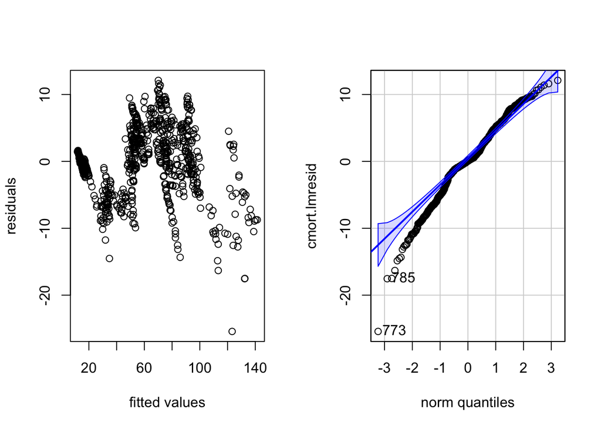

```
## [1] 773 785
```

```r
cmort.lmfits <- fitted(lmr_model)
cmort.lmresid <- resid(lmr_model)
par(mfrow=c(1,2))
plot(cmort.lmfits, cmort.lmresid, main = "", xlab = "fitted values",
     ylab = "residuals")
car::qqPlot(cmort.lmresid, main = "")
```

```r
#checking for aliases with estimate as 0
alias_model <- alias(lm(Total..Industrial.product.price.index..IPPI. ~ ., data = as.data.frame(industrial.price.data)))
num_aliased <- sum(alias_model$Estimate == 0)
print(num_aliased)
```

```
## [1] 0
```

```r
#principle component analysis
pca_result <- prcomp(as.matrix(industrial.price.data), scale = TRUE)
pca_result
```

```
## Standard deviations (1, .., p=6):
## [1] 2.3754251 0.3751851 0.3257875 0.2794835 0.1406081 0.1121278
##
## Rotation (n x k) = (6 x 6):
##                                                      PC1          PC2
## Total..Industrial.product.price.index..IPPI.   0.4169591 -0.007442008
## Fresh.and.frozen.beef.and.veal...              0.4075023 -0.125338048
## Fresh.and.frozen.pork...                       0.3984933 -0.829557474
## Fresh.and.frozen.lamb..mutton.and.goat.meat... 0.4022116  0.302185246
## Complete.cattle.feed...                        0.4127607  0.338677517
## Complete.swine.feed...                         0.4112718  0.300084995
##                                                         PC3         PC4
## Total..Industrial.product.price.index..IPPI.    0.016408408  0.23679360
## Fresh.and.frozen.beef.and.veal...              -0.036756565 -0.87583948
## Fresh.and.frozen.pork...                        0.003651898  0.26414532
## Fresh.and.frozen.lamb..mutton.and.goat.meat...  0.826594024  0.10053599
## Complete.cattle.feed...                        -0.360769640 -0.03570605
## Complete.swine.feed...                         -0.430062751  0.30931996
##                                                       PC5         PC6
## Total..Industrial.product.price.index..IPPI.    0.8254777  0.29721336
## Fresh.and.frozen.beef.and.veal...               0.1140551 -0.19177542
## Fresh.and.frozen.pork...                       -0.2883462  0.01038499
## Fresh.and.frozen.lamb..mutton.and.goat.meat... -0.2141107 -0.08775737
## Complete.cattle.feed...                        -0.4181803  0.63923525
## Complete.swine.feed...                         -0.0414274 -0.67709342
```

```r
#checking for collinearity
vif_values <- vif(lmr_model)
vif_condition <- max(vif_values)/min(vif_values)
high_vif_variables <- names(vif_values[vif_values > vif_condition])
# Print the variables with high VIF
print(high_vif_variables)
```

```
## [1] "Fresh.and.frozen.beef.and.veal..."
## [2] "Fresh.and.frozen.pork..."
## [3] "Fresh.and.frozen.lamb..mutton.and.goat.meat..."
## [4] "Complete.cattle.feed..."
## [5] "Complete.swine.feed..."
```

```r
# Convert the result to a named list
high_vif_list <- as.list(setNames(high_vif_variables, high_vif_variables))
print(high_vif_list)
```

```
## $Fresh.and.frozen.beef.and.veal...
## [1] "Fresh.and.frozen.beef.and.veal..."
##
## $Fresh.and.frozen.pork...
## [1] "Fresh.and.frozen.pork..."
##
## $Fresh.and.frozen.lamb..mutton.and.goat.meat...
## [1] "Fresh.and.frozen.lamb..mutton.and.goat.meat..."
##
## $Complete.cattle.feed...
## [1] "Complete.cattle.feed..."
##
## $Complete.swine.feed...
## [1] "Complete.swine.feed..."
```

```r
#splitting the data based on the first 700 rows as train and the last rows as test data as the data is dependent
n.train <- 700 #length(train set)
train.alldat <- data.frame(industrial.price.data[1:n.train, ])
test.alldat <- data.frame(industrial.price.data[(n.train + 1):nrow(industrial.price.data), ])
```

```r
ts_res <- ts(train.alldat$Total..Industrial.product.price.index..IPPI., start = c(1956, 1) , end = c(2023, 11), frequency = 12 )
# Convert the dataframe to a multivariate time series object
#industrial.price.data_ <- industrial.price.data[, -c("Total..Industrial.product.price.index..IPPI." )]
# Assuming ts_multivariate is your multivariate time series
industrial.price.data_ <- train.alldat[, -which(names(train.alldat) == "Total..Industrial.product.price.index..IPPI.")]

ts_multivariate <- ts(industrial.price.data_, start = c(1956, 1), end = c(2023, 11), frequency = 12)

fit <- auto.arima(ts_res, xreg = ts_multivariate)

fit
```

```
## Series: ts_res
## Regression with ARIMA(0,1,1)(0,0,1)[12] errors
##
## Coefficients:
##          ma1    sma1  Fresh.and.frozen.beef.and.veal...
##       0.2070  0.0757                             0.2031
## s.e.  0.0342  0.0346                             0.0182
##       Fresh.and.frozen.pork...  Fresh.and.frozen.lamb..mutton.and.goat.meat...
##                         0.1274                                          0.1783
## s.e.                    0.0128                                          0.0182
##       Complete.cattle.feed...  Complete.swine.feed...
##                        0.4847                  0.0533
## s.e.                   0.0317                  0.0237
##
## sigma^2 = 0.6185:  log likelihood = -956.03
## AIC=1928.07   AICc=1928.25   BIC=1965.68
```

**Model Specification:** ARIMA(0,1,1): The model includes a moving average (MA) component of order 1, and a differencing of order 1. This suggests that the first difference of the series is used to achieve stationarity, and a one-period lag of the errors is included in the model. Seasonal Component: There is a seasonal component with a lag of 12 (monthly seasonality).

**Coefficients:** ma1 (Moving Average): The coefficient for the moving average term is 0.2070, indicating the strength and direction of the impact of the moving average on the series. sma1 (Seasonal Moving Average): The coefficient for the seasonal moving average term is 0.0757.

**Coefficients for Predictors:** The coefficients for the predictor variables (Fresh and frozen beef and veal, pork, lamb, complete cattle feed, complete swine feed) represent their respective contributions to the time series. For example, a unit increase in Fresh and frozen beef and veal is associated with an increase of 0.2031 in the series, holding other factors constant.

**Standard Errors:** s.e. (Standard Error): These values represent the standard errors associated with each coefficient estimate. They provide a measure of the uncertainty or precision of the estimates.

**Model Fit:** Sigma^2 (Variance of Errors): The estimated variance of the errors (residuals) is 0.6185. Log Likelihood: The log likelihood is -956.03, indicating the maximized log likelihood of the model. AIC, AICc, BIC: These are information criteria used for model selection. Lower values indicate a better-fitting model. In this case, AIC=1928.07, AICc=1928.25, and BIC=1965.68.

**Interpretation:** The ARIMA model with the specified parameters and predictor variables is fitted to the time series data. Coefficients and their standard errors provide insights into the impact of each component on the series. The information criteria (AIC, AICc, BIC) help evaluate the model’s goodness of fit and guide model selection.

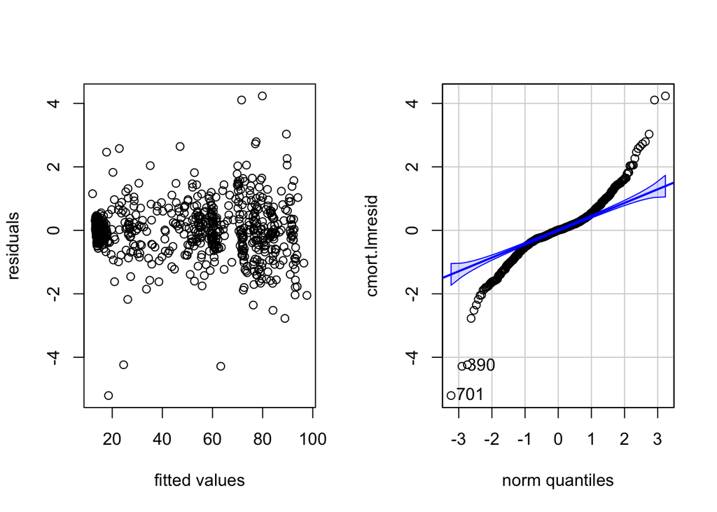

```
## [1] 701 390
```

```r
cmort.lmfits <- fitted(fit)
cmort.lmresid <- resid(fit)
par(mfrow=c(1,2))
plot(cmort.lmfits, cmort.lmresid, main = "", xlab = "fitted values",
     ylab = "residuals")
car::qqPlot(cmort.lmresid, main = "")
```

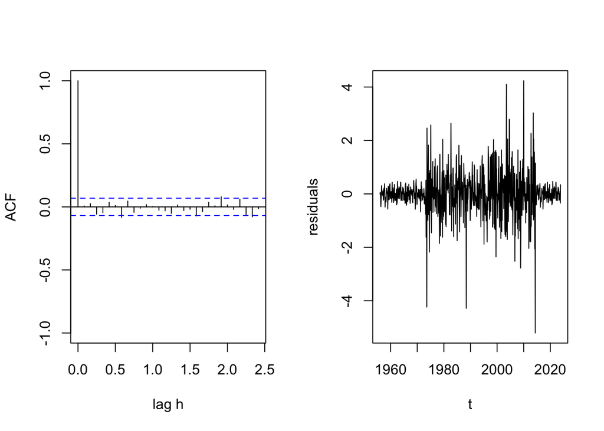

```r
acf(resid(fit), ylim = c(-1, 1), main = "", xlab = "lag h")

ts.plot(cmort.lmresid, ylab = "residuals", xlab = "t")
```

In the residual quantile-quantile plot, deviations of data points from the center line are noticeable on both sides. However, in the autocorrelation function plot, it is evident that the data points consistently fall below the blue dotted line, indicating a positive signal.

Following code is to predict values on the test data by the model fitted above

```r
#test data forecast
regmat.test <- as.matrix(test.alldat[, -which(names(train.alldat) == "Total..Industrial.product.price.index..IPPI.")])
armaxfcst.all <- forecast(fit, xreg = regmat.test)
armaxfcst.all
```

```
##          Point Forecast     Lo 80     Hi 80     Lo 95     Hi 95
## Dec 2023       88.64942  87.64152  89.65732  87.10797  90.19087
## Jan 2024       88.70126  87.12143  90.28109  86.28512  91.11741
## Feb 2024       89.50020  87.50624  91.49416  86.45070  92.54969
## Mar 2024       88.74308  86.40729  91.07886  85.17081  92.31534
## Apr 2024       90.02669  87.39309  92.66030  85.99894  94.05444
## May 2024       88.33547  85.43446  91.23649  83.89876  92.77219
## Jun 2024       89.00503  85.85926  92.15080  84.19399  93.81607
## Jul 2024       90.66282  87.29001  94.03564  85.50455  95.82110
## Aug 2024       92.47105  88.88553  96.05656  86.98748  97.95461
## Sep 2024       93.09879  89.31251  96.88507  87.30818  98.88940
## Oct 2024       92.84681  88.86989  96.82373  86.76464  98.92899
## Nov 2024       91.56275  87.40391  95.72158  85.20236  97.92313
## Dec 2024       90.96267  86.60753  95.31782  84.30205  97.62330
## Jan 2025       91.15672  86.60921  95.70422  84.20191  98.11152
## Feb 2025       93.30273  88.57068  98.03478  86.06568 100.53977
## Mar 2025       93.61080  88.70114  98.52046  86.10212 101.11948
## Apr 2025       93.38422  88.30315  98.46529  85.61340 101.15505
## May 2025       91.94558  86.69870  97.19246  83.92117  99.96999
## Jun 2025       90.54765  85.14004  95.95526  82.27742  98.81787
## Jul 2025       89.58320  84.01950  95.14690  81.07426  98.09214
## Aug 2025       90.90191  85.18639  96.61744  82.16077  99.64306
## Sep 2025       91.38265  85.51923  97.24608  82.41532 100.34998
## Oct 2025       89.50640  83.49872  95.51408  80.31845  98.69435
## Nov 2025       88.69262  82.54407  94.84117  79.28922  98.09602
## Dec 2025       88.00987  81.72361  94.29614  78.39586  97.62389
## Jan 2026       91.02670  84.60567  97.44774  81.20658 100.84683
## Feb 2026       90.50075  83.94772  97.05378  80.47876 100.52274
## Mar 2026       86.78063  80.09822  93.46304  76.56076  97.00050
## Apr 2026       85.56147  78.75213  92.37081  75.14748  95.97546
## May 2026       85.14959  78.21564  92.08353  74.54503  95.75414
## Jun 2026       82.40766  75.35130  89.46401  71.61590  93.19942
## Jul 2026       81.46387  74.28720  88.64054  70.48810  92.43964
## Aug 2026       83.72737  76.43236  91.02237  72.57062  94.88411
## Sep 2026       84.49990  77.08845  91.91135  73.16507  95.83474
## Oct 2026       85.63255  78.10646  93.15864  74.12238  97.14272
## Nov 2026       85.59948  77.96046  93.23849  73.91661  97.28234
## Dec 2026       86.43969  78.68939  94.18998  74.58664  98.29274
## Jan 2027       87.35822  79.49822  95.21822  75.33739  99.37905
## Feb 2027       86.62725  78.65906  94.59544  74.44096  98.81355
```

[output cut: 61 more lines]

```
## Apr 2032      135.77416 122.74856 148.79977 115.85322 155.69511
## May 2032      136.19316 123.10199 149.28434 116.17194 156.21439
## Jun 2032      137.50230 124.34588 150.65872 117.38130 157.62331
## Jul 2032      137.40067 124.17933 150.62201 117.18038 157.62097
## Aug 2032      139.46990 126.18396 152.75585 119.15080 159.78900
## Sep 2032      139.16383 125.81359 152.51406 118.74640 159.58125
## Oct 2032      139.16761 125.75339 152.58183 118.65233 159.68289
## Nov 2032      139.73171 126.25381 153.20961 119.11904 160.34438
## Dec 2032      138.57707 125.03579 152.11835 117.86747 159.28667
## Jan 2033      137.02507 123.42071 150.62944 116.21899 157.83116
## Feb 2033      132.90046 119.23330 146.56762 111.99834 153.80258
## Mar 2033      133.66604 119.93637 147.39570 112.66832 154.66375
## Apr 2033      132.78391 118.99202 146.57580 111.69104 153.87679
## May 2033      132.52577 118.67193 146.37960 111.33816 153.71338
## Jun 2033      132.02207 118.10657 145.93757 110.74014 153.30399
```

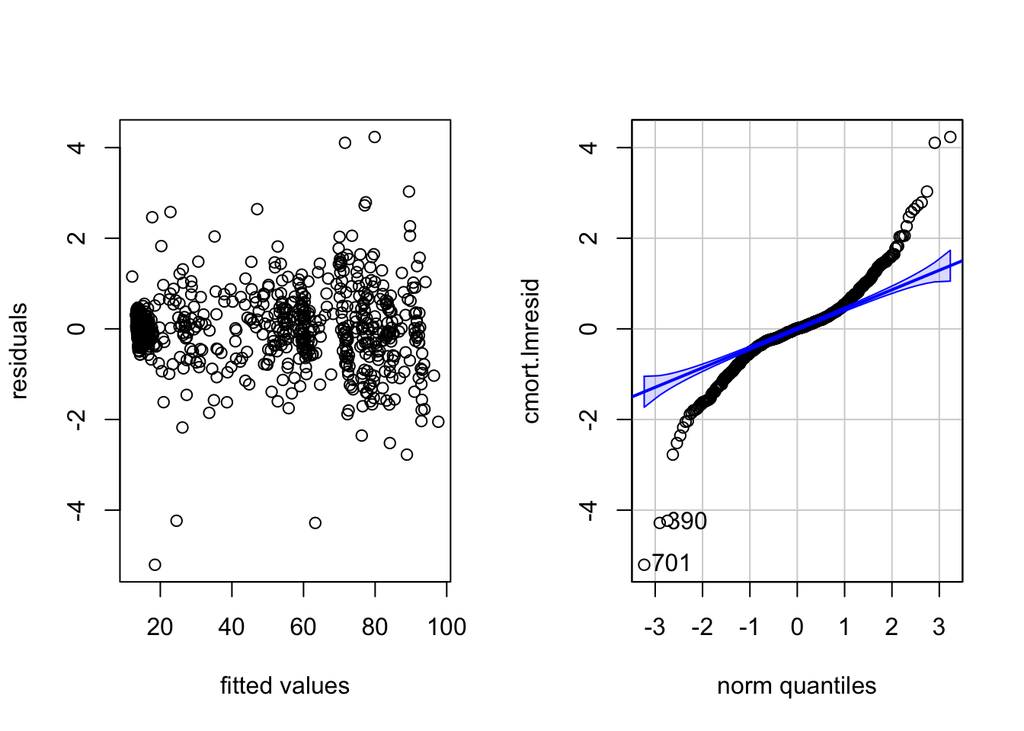

```
## [1] 701 390
```

```r
cmort.lmfits <- fitted(armaxfcst.all)
cmort.lmresid <- resid(armaxfcst.all)
par(mfrow=c(1,2))
plot(cmort.lmfits, cmort.lmresid, main = "", xlab = "fitted values",
     ylab = "residuals")
car::qqPlot(cmort.lmresid, main = "")
```

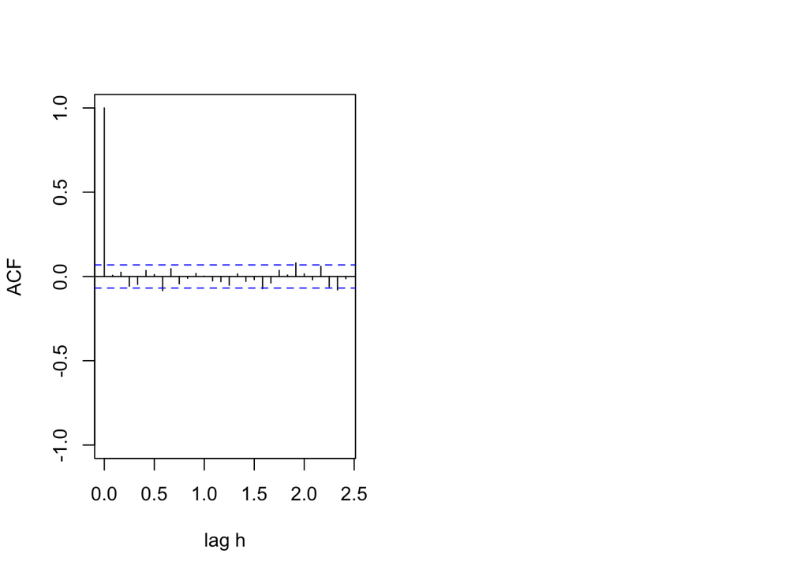

```r
acf(resid(armaxfcst.all), ylim = c(-1, 1), main = "", xlab = "lag h")
```

In the residual quantile-quantile plot, deviations of data points from the center line are noticeable on both sides. However, in the autocorrelation function plot, it is evident that the data points consistently fall below the blue dotted line, indicating a positive signal.

```r
(armaxfcst <- armaxfcst.all$mean)
```

```
##            Jan       Feb       Mar       Apr       May       Jun       Jul
## 2023
## 2024  88.70126  89.50020  88.74308  90.02669  88.33547  89.00503  90.66282
## 2025  91.15672  93.30273  93.61080  93.38422  91.94558  90.54765  89.58320
## 2026  91.02670  90.50075  86.78063  85.56147  85.14959  82.40766  81.46387
## 2027  87.35822  86.62725  85.39302  84.62118  85.29666  86.42738  87.13571
## 2028  91.83950  91.15007  90.06965  90.49483  90.14944  88.86299  90.44917
## 2029  94.80596  93.56348  94.42157  92.49893  92.88773  93.43735  94.71137
## 2030 109.31391 100.65239 100.16960 102.55889 103.45228 107.35519 105.66043
## 2031 126.81789 123.42730 129.66454 130.56846 125.38179 127.19044 126.42198
## 2032 142.04407 138.84172 136.29544 135.77416 136.19316 137.50230 137.40067
## 2033 137.02507 132.90046 133.66604 132.78391 132.52577 132.02207
##            Aug       Sep       Oct       Nov       Dec
## 2023                                          88.64942
## 2024  92.47105  93.09879  92.84681  91.56275  90.96267
## 2025  90.90191  91.38265  89.50640  88.69262  88.00987
## 2026  83.72737  84.49990  85.63255  85.59948  86.43969
## 2027  88.66057  89.44463  90.23803  90.79289  92.70517
## 2028  91.29850  90.54603  91.86777  94.07464  94.27548
## 2029 101.91011 100.69863 103.52242 112.50888 117.95372
## 2030 109.40347 113.63634 116.04601 120.65249 126.94912
## 2031 129.76152 134.79846 137.89072 140.23908 142.24513
## 2032 139.46990 139.16383 139.16761 139.73171 138.57707
## 2033
```

```r
(armaxfcsterr <- test.alldat$Total..Industrial.product.price.index..IPPI. - armaxfcst)
```

```
##               Jan          Feb          Mar          Apr          May
## 2023
## 2024   6.19873850   5.19980284   6.15692482   4.57330926   5.66452649
## 2025   3.04328387   1.59727392   0.88920043   0.71577701   1.75441804
## 2026   2.47329518   3.29924964   6.71936974   8.23852898   9.45041460
## 2027   9.14178080   8.47274772  10.00698492  10.47882453  10.80333690
## 2028   9.76050144  10.14992509  10.73035188  10.50516926  10.95055849
## 2029   5.09403981   6.03652326   5.37842794   7.20106578   6.81227318
## 2030 -11.31391073  -1.55238906  -0.06960018  -1.75888825  -2.55228179
## 2031 -11.81788897  -8.42730047 -15.06453664 -14.56845582  -7.78179169
## 2032 -10.44406952 -10.44172193  -9.79543541  -9.47416458  -6.99316281
## 2033 -12.72507274  -8.60046241  -7.16603574  -5.78391368  -6.72576924
##               Jun          Jul          Aug          Sep          Oct
## 2023
## 2024   4.69496993   1.53717616  -0.47104558   0.70121025   1.15318664
```

[output cut: 21 more lines]

ME and MPE measure the bias in the forecasts. Values close to 0 indicate a better model.

MSE, MAE, and MAPE measure the accuracy of the forecasts. Small values of these indicate a better model. Note that MAPE is a percentage, which is computed to be agnostic to the scale of the response, and is widely used for selecting the best model.

We evaluate the forecast validity criteria ME, MPE, MSE, MAE, and MAPE for cmort using the setup shown below.

```r
(me.armaxfcst <- mean(armaxfcsterr))  #ME
```

```
## [1] 0.4067705
```

```r
(mpe.armaxfcst <- 100*(mean(armaxfcsterr/test.alldat$Total..Industrial.product.price.index..IPPI.))) # MPE
```

```
## [1] 1.047218
```

```r
(mse.armaxfcst <- sum(armaxfcsterr**2)/nrow(test.alldat))      # MSE
```

```
## [1] 73.33222
```

```r
(mae.armaxfcst <- mean(abs(armaxfcsterr)))                # MAE
```

```
## [1] 7.580809
```

```r
(mape.armaxfcst <- 100*mean(abs(armaxfcsterr/test.alldat$Total..Industrial.product.price.index..IPPI.))) # MAPE
```

```
## [1] 7.160024
```